# Sleep – Paired Samples t Test

#### Background

An experiment was conducted to determine which of two soporific drugs was better at increasing the hours of sleep individuals received, on average. Ten patients took each of the two drugs at different times. The amount of extra sleep that each individual received when using each drug was measured. The data is contained in the `sleep` data set. Note that the variable `group` would be better labeled as `drug` because the 10 individuals in each group are the same individuals as shown in the `ID` column.

| extra | group | ID |
| --- | --- | --- |
| 0.7 | 1 | 1 |
| -1.6 | 1 | 2 |
| -0.2 | 1 | 3 |
| -1.2 | 1 | 4 |
| -0.1 | 1 | 5 |
| 3.4 | 1 | 6 |
| 3.7 | 1 | 7 |
| 0.8 | 1 | 8 |
| 0.0 | 1 | 9 |
| 2.0 | 1 | 10 |
| 1.9 | 2 | 1 |
| 0.8 | 2 | 2 |
| 1.1 | 2 | 3 |
| 0.1 | 2 | 4 |
| -0.1 | 2 | 5 |
| 4.4 | 2 | 6 |
| 5.5 | 2 | 7 |
| 1.6 | 2 | 8 |
| 4.6 | 2 | 9 |
| 3.4 | 2 | 10 |

The only point of interest in this study is the difference in hours of extra sleep each individual received under the two drugs. Hence, this is a paired study as two measurements were obtained for each individual, one measurement under each condition.

Formally, the null and alternative hypotheses are written as
$$H_0: \mu_d = 0$$
$$H_a: \mu_d \neq 0$$

The significance level for this study will be set at
$$\alpha = 0.05$$

Note that the $\neq$ alternative hypothesis allows for either possibility, $\mu_d > 0$ or $\mu_d < 0$. If we selected a one-sided hypothesis, then only the stated alternative is considered possible, or of interest.

#### Analysis

The dotplot below shows the differences (drug 2 extra sleep $-$ drug 1 extra sleep) in extra sleep for each individual. Since 9 out of 10 differences are positive, it shows that most individuals are getting more extra sleep while using drug 2 than when using drug 1.

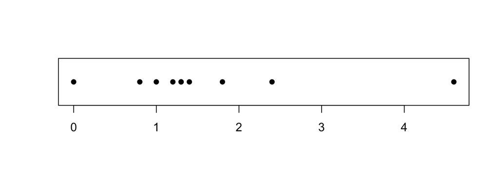

```r
with(sleep,
     stripchart(extra[group==2]-extra[group==1], pch=16)
)
```

The paired samples t test is only appropriate if the sampling distribution of the sample mean of the differences, $\bar{d}$, is normally distributed.

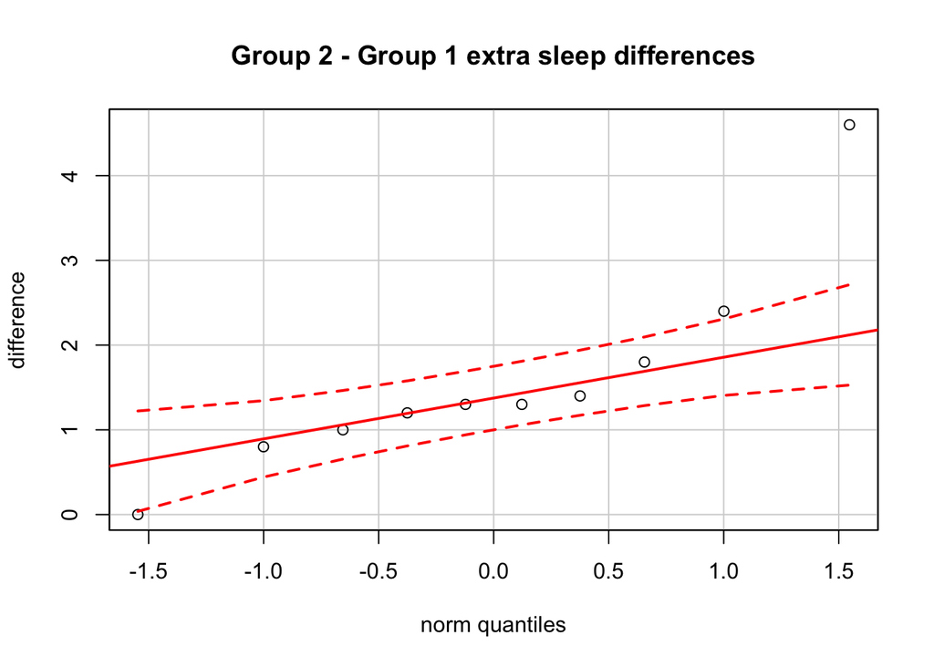

```r
with(sleep,
     qqPlot(extra[group==2]-extra[group==1], ylab="difference", main="Group 2 - Group 1 extra sleep differences")
)
```

Based on the QQ-Plots above, it appears that the normality assumption of the differences is questionable. The paired samples t test will be performed, but the validity of the test is highly questionable. It would be better to use a nonparametric test for these data, like the Wilcoxon Test.

```r
pander(with(sleep,
            t.test(sleep$extra[group==1], sleep$extra[group==2], paired = TRUE, mu = 0, alternative = "two.sided", conf.level = 0.95)
))
```

Paired t-test: `sleep$extra[group == 1]` and `sleep$extra[group == 2]`

| Test statistic | df | P value | Alternative hypothesis |
| --- | --- | --- | --- |
| -4.062 | 9 | 0.002833 * * | two.sided |

There is sufficient evidence to reject the null hypothesis ($p = 0.002833 < \alpha$).

#### Interpretation

Becaues the results of the Paired Samples t Test were significant, we can conclude that the patterns in the data stated above can be considered to apply to the general population. However, the assumptions of the test were not shown to be satisfied, so the results of this test are questionable. Before concluding that drug 2 provides more extra sleep for most individuals in the full population than does drug 1, it is necessary to perform a nonparametric paired samples test. (Fortunately, when this the nonparametric version of the test is performed, a similar result is obtained. So we are able to safely conclude that drug 2 out performs drug 1.)